# Assignment 3: Model comparison

Marton Kovacs

In this lab assignment you are going to work with (simulated) data related to perioperative pain and its psychological and hormonal predictors. In the assignment you will assess the added benefit of including some psychological and hormonal predictors to the already established demographic predictors of pain.

In this assignment you will set up a hierarchical regression model to predict postoperative pain after wisdom tooth surgery.

# Research problem

The amount of pain experienced around and after surgeries are highly variable between and within individuals. In order to improve surgical pain management regimens we need to understand what influences pain around surgical procedures and predict the amount of pain an individual will experience.

Your first study in this area is related to assessing the influence of trait and state psychological measures on pain, and to see whether taking into account these variables can improve our understanding of postoperative pain.

# Procedures and measures

Use the data file called ‘assignment_3_dataset’, from the ‘data/’ folder.

You have collected data from 160 adults who were scheduled to undergo surgical extraction of the third mandibular molar (wisdom tooth surgery). Patients filled out a form in the waiting room before their surgery. The form contained questions about their sex, age, and weight, and psychological questionnaires assessing anxiety, pain catastrophizing, and mindfulness (see descriptions below). You also got blood samples and saliva samples from participants in the waiting room 5 minutes before their operations to determine the serum (a component of the blood) and salivary cortisol levels of participants. Participants were contacted 5 hours after the surgery to see how much pain they were experiencing. The **level of pain** at that moment was recorded using a numerical rating scale using a **scale of 0 to 10**, where 0 means “no pain” and 10 means “worst pain I can imagine”.

**The State Trait Anxiety Inventory:** T measures trait anxiety on a scale of 20 to 80, higher scores mean higher anxiety. Anxiety has been found in many studies to positively correlate with the level of pain experienced. This is **variable STAI_trait** in the dataset.

**The Pain Catastrophizing Scale** measures the extent of pain catastrophizing, which is characterized by a tendency to magnify the threat value of a pain stimulus and to feel helpless in the presence of pain, as well as by a relative inability to prevent or inhibit pain-related thoughts in anticipation of, during, or following a painful event. The total score on this scale ranges from 0 to 52, higher scores mean higher catastrophizing. Pain catastrophizing is one of the well-established predictors of clinical pain. This is **variable pain_cat** in the dataset.

**The Mindful Attention Awareness Scale (MAAS)** measures dispositional mindfulness, which may be described as a tendency to turn attention to present-moment experiences in an open, non-judgmental way. The MAAS total score ranges from 1 to 6 (an average of the item scores), with higher scores representing higher dispositional mindfulness. Trait mindfulness has been theorized to serve as a protective factor against pain, as the individual would be more objective about their pain experience and tend to associate less discomfort, despair, and hopelessness to the pain-related sensations. This is **variable mindfulness** in the dataset.

**Cortisol** is a stress hormone associated with acute and chronic stress. Cortisol levels are thought to be positively associated with pain experience. Cortisol can be **measured from both blood and the saliva**, although, serum cortisol is often regarded in medical research as more reliably related to stress (serum is a component of the blood plasma). These are **variables cortisol_serum**, and **cortisol_saliva** in the dataset.

# Research question

Previous studies and meta-analyses showed that age and sex are often predictors of pain (age is negatively associated with pain, while sex is a predictor more dependent on the type of the procedure). You would like to determine the extent to which taking into account psychological and hormonal variables aside from the already used demographic variables would improve our understanding of postoperative pain.

To answer this research question you will **need to compare two models** (with a hierarchical regression). The **simpler model** should contain **age and sex as predictors of pain**, while the **more complex model** should contain the **predictors: age, sex, STAI, pain catastrophizing, mindfulness, and cortisol measures**. Notice that the predictors used in the simpler model are a subset of the predictors used in more complex model. **You will have to do model comparison to assess whether substantial new information was gained about pain in the more complex model compared to the simpler model.**

# What to report

As usual, before you can interpret your model, you will need to run data and model diagnostics. First, check the variables included in the more complex model (age, sex, STAI, pain catastrophizing, mindfulness, and cortisol measures as predictors, and pain as an outcome) for **coding errors**, and the model itself for **influential outliers** (for example using Cook’s distance). Furthermore, check the final model to see if the **assumptions of linear regression hold true**, that is, **normality** (of the residuals), **linearity** (of the relationship), **homogeneity of variance** (also called homoscedasticity) and that there is no excess **multicollinearity** (“uncorrelated predictors” in Navarro’s words). If you find anything amiss during these checks, make the appropriate decision or correction and report your findings and actions in your report.

**Note:** If you do any changes, such as exclude cases, or exclude predictors from the model, you will have to re-run the above checks for your final data and model.

Report the results of the simpler model and the more complex model. For both models you should report the model test statistics (adj.R2, F, df, and p value). Also, report the statistics describing the coefficients of the predictors in a table format (unstandardized regression coefficients and 95% confidence intervals, standardized regression coefficients (B and Beta values), and p values).

Write up the regression equation of the more complex model in the form of 𝑌 = 𝑏0 + 𝑏1 ∗ X1 + 𝑏2 ∗ X2 +…+ bn * Xn, in which you use the actual regression coefficients of your models. (b0 stands for the intercept and b1, b2 … bn stand for the model coefficients for each of the predictors, and X1, X2, … Xn denote the predictors).

Compare the two models in terms of how much variance they explain of pain’s variability in the sample. Report Akaike information criterion (AIC) for both models and the F test statistic and p value of the likelihood ratio test comparing the two models.

# What to discuss

In your discussion of the findings, briefly interpret the results of the above analyses, and indicate whether you think that anything was gained by including the psychological and hormone measures in the model.

# Solution

## Read the data

Read the dataset used in this assignment. Pay attention to the extension of the datafile.

```r
require(readxl)
require(tidyverse)
temp = tempfile(fileext = ".xlsx")
dataURL <- "https://github.com/elte-ppk-r-course/public_r_data_analysis_2021_fall/blob/master/data/assignment_3_dataset.xlsx?raw=true"
download.file(dataURL, destfile=temp, mode='wb')

wisdom<- readxl::read_excel(temp)
```

## Data and model diagnostics

### Data diagnostics

#### Descriptives of the variables

Run an exploratory data analysis (EDA) to investigate the dataset.

```r
str(wisdom)
```

```
## tibble [160 x 12] (S3: tbl_df/tbl/data.frame)
##  $ ID              : chr [1:160] "ID_1" "ID_2" "ID_3" "ID_4" ...
##  $ pain            : num [1:160] 5 4 5 7 4 6 4 5 4 5 ...
##  $ sex             : chr [1:160] "female" "female" "female" "female" ...
##  $ age             : num [1:160] 38 36 51 39 48 45 45 35 39 33 ...
##  $ STAI_trait      : num [1:160] 39 46 49 48 36 37 34 39 31 38 ...
##  $ pain_cat        : num [1:160] 25 31 32 41 26 28 22 32 27 36 ...
##  $ cortisol_serum  : num [1:160] 4.67 6.01 5.18 6.65 2.95 4.32 5.32 5.26 3.36 5.96 ...
##  $ cortisol_saliva : num [1:160] 4.78 6.71 4.75 6.68 3.2 4.36 5.19 5.53 3.3 5.78 ...
##  $ mindfulness     : num [1:160] 3.83 2.82 3.93 1.9 4.39 3.01 4.97 2.95 3.43 1.85 ...
##  $ weight          : num [1:160] 62.1 97.1 79 78.5 76.9 ...
##  $ IQ              : num [1:160] 99 71 97 97 129 115 74 98 93 76 ...
##  $ household_income: num [1:160] 52505 64993 68598 47822 100580 ...
```

```r
# Fix discrete vars

wisdom$sex <- as.factor(wisdom$sex)

#check colnames
colnames(wisdom)
```

```
##  [1] "ID"               "pain"             "sex"              "age"
##  [5] "STAI_trait"       "pain_cat"         "cortisol_serum"   "cortisol_saliva"
##  [9] "mindfulness"      "weight"           "IQ"               "household_income"
```

```r
# Check Nas
table(is.na(wisdom)) # all Nas
```

```
##
## FALSE
##  1920
```

```r
## Checking Means and Deviations, ranges
#remove discrete vars


# Identifying incorrect ranges
require(spatstat.utils)
pain.var <- c(1,10)
stai.var <- c(20,80)
pain_cat.var <- c(0 ,52)
maas.var <- c(1,6)
incorr <- NULL

if(nrow(wisdom)-sum(inside.range(wisdom$pain, pain.var))> 0)
  {incorr <- names(wisdom[2])}
if(nrow(wisdom)-sum(inside.range(wisdom$STAI_trait, stai.var))> 0)
  {incorr <- append(incorr, names(wisdom[5]))}
if(nrow(wisdom)-sum(inside.range(wisdom$pain_cat, pain_cat.var))> 0)
  {incorr <- append(incorr, names(wisdom[6]))}
if(nrow(wisdom)-sum(inside.range(wisdom$mindfulness, maas.var))> 0)
  {incorr <- append(incorr, names(wisdom[9]))}


#to be corrected
incorr
```

```
## [1] "pain"        "mindfulness"
```

#### Correct coding errors

If you find values in the dataset during the EDA, that are not correct based on the provided descriptions of the variables of the dataset please correct them here.

```r
# omitting rows with incorrect range values
incorr
```

```
## [1] "pain"        "mindfulness"
```

```r
wisdom <- wisdom[-which(wisdom$pain > 10),]
wisdom <- wisdom[-which(wisdom$mindfulness>6),]

# 1 coding error in sex var.

wisdom$sex[wisdom$sex == "woman"] <- "female"
wisdom$sex <- factor(wisdom$sex)

#reduce dataset for vars we actually use
wisdom <- wisdom[,-c(1, 10:12)]
wisdom.num <- wisdom[-c(2)] #only numericals
```

### Model diagnostics

#### Build the more complex model

In order to test the more complex model for outliers and to test the assumptions first build the model.

```r
#build complex model

model.comp <- lm(pain ~
                   age +
                   sex +
                   STAI_trait +
                   pain_cat +
                   mindfulness +
                   cortisol_serum +
                   cortisol_saliva, data = wisdom)
```

#### Checking for influential outliers

Check for outlier values in the model.

```r
## check Mahalanobis distance for outliers

mahal <- mahalanobis(wisdom.num,
                     colMeans(wisdom.num, na.rm = T),
                     cov(wisdom.num, use = "pairwise.complete.obs"))

## create cutoff score for extreme datapoints
cutoff = qchisq(1-0.001, ncol(wisdom.num))
cutoff # our cutoff score
```

```
## [1] 24.32189
```

```r
ncol(wisdom.num) # degrees of freedom
```

```
## [1] 7
```

```r
mahal.out <- as.numeric(mahal > cutoff)
table(mahal.out)
```

```
## mahal.out
##   0
## 158
```

```r
## leverage
k = 7 ##number of IVs in the final step
leverage <- hatvalues(model.comp)
cutleverage <- (2*k+2) / nrow(wisdom)
cutleverage ##cut off
```

```
## [1] 0.1012658
```

```r
overleverage <-  as.numeric(leverage > cutleverage)
table(overleverage)
```

```
## overleverage
##   0   1
## 152   6
```

```r
## cooks
cooks = cooks.distance(model.comp)
cutcooks = 4 / (nrow(wisdom) - k - 1)
cutcooks ##get the cut off
```

```
## [1] 0.02666667
```

```r
bad.cooks = as.numeric(cooks > cutcooks)
table(bad.cooks)
```

```
## bad.cooks
##   0   1
## 148  10
```

```r
## overall outliers
total.out <- mahal.out + overleverage + bad.cooks
table(total.out)
```

```
## total.out
##   0   1   2
## 143  14   1
```

```r
## remove outliers that fail even on 1 criteria. We have enogh obs. not to lose much stat.power

noout <- subset(wisdom, total.out < 1)

## rebuilding complex model with outliers addressed

model.comp <- lm(pain ~
                   age +
                   sex +
                   STAI_trait +
                   pain_cat +
                   mindfulness +
                   cortisol_serum +
                   cortisol_saliva, data = noout)
```

#### Additivity

```r
summary(model.comp, correlation = T) #cortisol variables too highly correlated
```

```
##
## Call:
## lm(formula = pain ~ age + sex + STAI_trait + pain_cat + mindfulness +
##     cortisol_serum + cortisol_saliva, data = noout)
##
## Residuals:
##      Min       1Q   Median       3Q      Max
## -2.77568 -0.72104 -0.05881  0.72351  2.56313
##
## Coefficients:
##                  Estimate Std. Error t value Pr(>|t|)
## (Intercept)      0.686433   1.689373   0.406  0.68515
## age             -0.026931   0.024365  -1.105  0.27098
## sexmale          0.359276   0.202864   1.771  0.07881 .
## STAI_trait      -0.001962   0.027853  -0.070  0.94394
## pain_cat         0.090177   0.031261   2.885  0.00456 **
## mindfulness     -0.086506   0.123757  -0.699  0.48576
## cortisol_serum  -0.034292   0.259044  -0.132  0.89488
## cortisol_saliva  0.608570   0.263576   2.309  0.02247 *
## ---
## Signif. codes:  0 '***' 0.001 '**' 0.01 '*' 0.05 '.' 0.1 ' ' 1
##
## Residual standard error: 1.109 on 135 degrees of freedom
## Multiple R-squared:  0.3938, Adjusted R-squared:  0.3624
## F-statistic: 12.53 on 7 and 135 DF,  p-value: 2.61e-12
##
## Correlation of Coefficients:
##                 (Intercept) age   sexmale STAI_trait pain_cat mindfulness
## age             -0.67
## sexmale         -0.07       -0.11
## STAI_trait      -0.04       -0.49  0.22
## pain_cat        -0.57        0.41 -0.20   -0.42
## mindfulness     -0.64        0.18 -0.08    0.12       0.38
## cortisol_serum   0.13       -0.14 -0.02    0.09      -0.29    -0.09
## cortisol_saliva -0.26        0.31  0.09   -0.28       0.24     0.11
##                 cortisol_serum
## age
## sexmale
## STAI_trait
## pain_cat
## mindfulness
## cortisol_serum
## cortisol_saliva -0.89
```

```r
## remove serum from model as it is the least correlated with the DV

model.comp1 <- lm(pain ~
                   age +
                   sex +
                   STAI_trait +
                   pain_cat +
                   mindfulness +
                   cortisol_saliva, data = noout)

summary(model.comp, correlation = T)
```

```
##
## Call:
## lm(formula = pain ~ age + sex + STAI_trait + pain_cat + mindfulness +
##     cortisol_serum + cortisol_saliva, data = noout)
##
## Residuals:
##      Min       1Q   Median       3Q      Max
## -2.77568 -0.72104 -0.05881  0.72351  2.56313
##
## Coefficients:
##                  Estimate Std. Error t value Pr(>|t|)
## (Intercept)      0.686433   1.689373   0.406  0.68515
## age             -0.026931   0.024365  -1.105  0.27098
## sexmale          0.359276   0.202864   1.771  0.07881 .
## STAI_trait      -0.001962   0.027853  -0.070  0.94394
## pain_cat         0.090177   0.031261   2.885  0.00456 **
## mindfulness     -0.086506   0.123757  -0.699  0.48576
## cortisol_serum  -0.034292   0.259044  -0.132  0.89488
## cortisol_saliva  0.608570   0.263576   2.309  0.02247 *
## ---
## Signif. codes:  0 '***' 0.001 '**' 0.01 '*' 0.05 '.' 0.1 ' ' 1
##
## Residual standard error: 1.109 on 135 degrees of freedom
## Multiple R-squared:  0.3938, Adjusted R-squared:  0.3624
## F-statistic: 12.53 on 7 and 135 DF,  p-value: 2.61e-12
##
## Correlation of Coefficients:
##                 (Intercept) age   sexmale STAI_trait pain_cat mindfulness
## age             -0.67
## sexmale         -0.07       -0.11
## STAI_trait      -0.04       -0.49  0.22
## pain_cat        -0.57        0.41 -0.20   -0.42
## mindfulness     -0.64        0.18 -0.08    0.12       0.38
## cortisol_serum   0.13       -0.14 -0.02    0.09      -0.29    -0.09
## cortisol_saliva -0.26        0.31  0.09   -0.28       0.24     0.11
##                 cortisol_serum
## age
## sexmale
## STAI_trait
## pain_cat
## mindfulness
## cortisol_serum
## cortisol_saliva -0.89
```

#### Checking assumptions

```r
## setting up vars for assumptions

standardized <- rstudent(model.comp1) #standardized residuals
fitted <- scale(model.comp1$fitted.values) #fitted values scaled
```

Check the normality assumption.

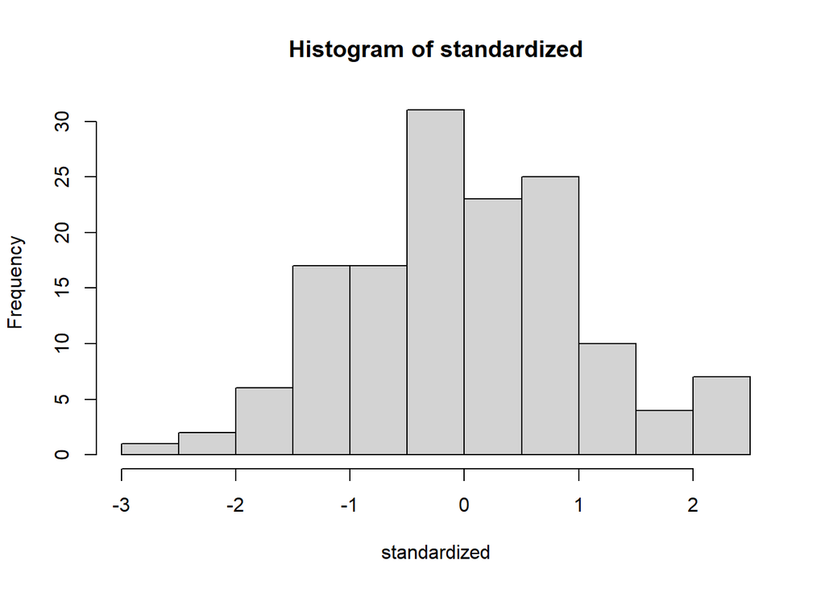

```r
hist(standardized) # close to normal
```

Check the linearity assumption.

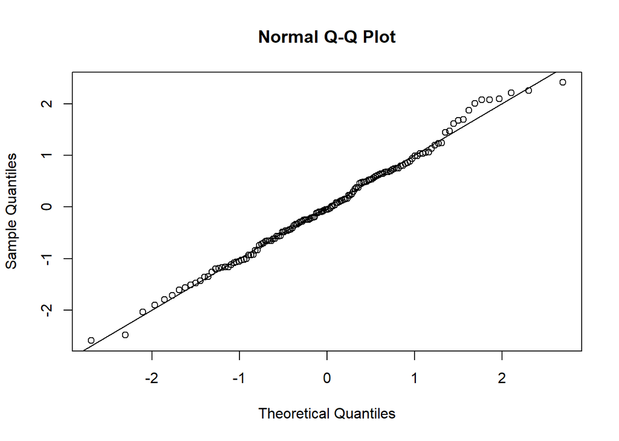

```r
qqnorm(standardized)
abline(0,1) #close to linear
```

Check the homoscedasticty assumption (homogeneity of variance).

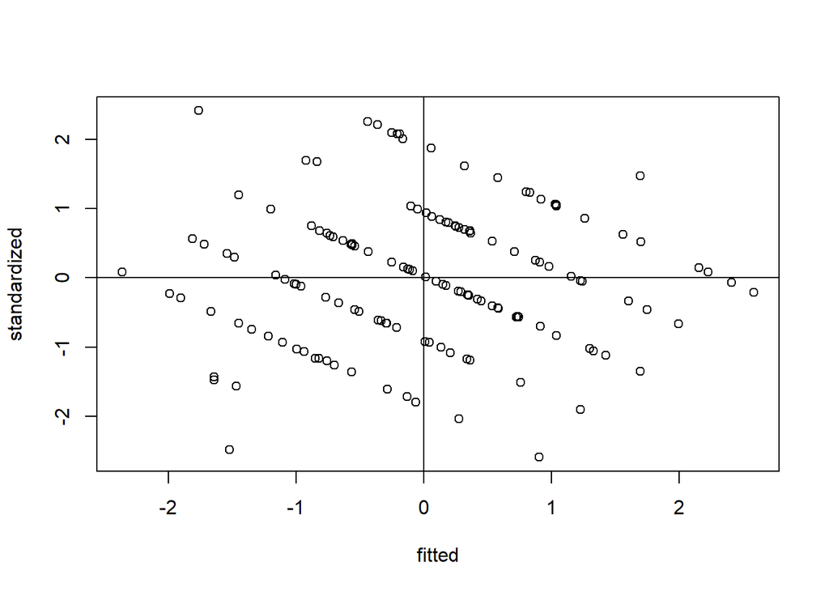

```r
plot(fitted, standardized)
abline(0,0)
abline(v=0)
```

```r
#even distribution and shape
```

Check the multicollinearity assumption.

(VIF above 5), or a VIF threshold of 3 is recommended in this paper: http://onlinelibrary.wiley.com/doi/10.1111/j.2041-210X.2009.00001.x/full

Some info about VIF: https://statisticalhorizons.com/multicollinearity http://blog.minitab.com/blog/understanding-statistics/handling-multicollinearity-in-regression-analysis

```r
require(car)
vif(model.comp1)
```

```
##             age             sex      STAI_trait        pain_cat     mindfulness
##        1.591115        1.192992        2.196188        1.882257        1.476234
## cortisol_saliva
##        1.747773
```

```r
# all of them are below 3
```

### Making decision based on model diagnostics

If based on the assumption tests you decide to drop a predictor variable you should do that here. Create your updated model.

This has already been done on an as-we-go basis. Changes include:

- removing outliers
- removing **cortisol_serum** predictor for high correlation with **cortisol_saliva**.* **Cortisol_saliva** had better correlation with our DV

#### Checking outliers of the updated model

```r
## check Mahalanobis distance for outliers

mahal1 <- mahalanobis(noout[,-2],
                     colMeans(noout[,-2], na.rm = T),
                     cov(noout[,-2], use = "pairwise.complete.obs"))

## create cutoff score for extreme datapoints
cutoff1 = qchisq(1-0.001, ncol(noout))
cutoff1 # our cutoff score
```

```
## [1] 26.12448
```

```r
ncol(noout) # degrees of freedom
```

```
## [1] 8
```

```r
mahal.out1 <- as.numeric(mahal1 > cutoff1)
table(mahal.out1)
```

```
## mahal.out1
##   0
## 143
```

```r
## leverage
k1 = 6 ##number of IVs in the final step
leverage1 <- hatvalues(model.comp1)
cutleverage1 <- (2*k+2) / nrow(noout)
cutleverage1 ##cut off
```

```
## [1] 0.1118881
```

```r
overleverage1 <-  as.numeric(leverage1 > cutleverage1)
table(overleverage1)
```

```
## overleverage1
##   0
## 143
```

```r
## cooks
cooks1 = cooks.distance(model.comp1)
cutcooks1 = 4 / (nrow(noout) - k - 1)
cutcooks1 ##get the cut off
```

```
## [1] 0.02962963
```

```r
bad.cooks1 = as.numeric(cooks1 > cutcooks1)
table(bad.cooks1)
```

```
## bad.cooks1
##   0   1
## 134   9
```

```r
## overall outliers
total.out1 <- mahal.out1 + overleverage1 + bad.cooks1
table(total.out1)
```

```
## total.out1
##   0   1
## 134   9
```

```r
##no outiers that violate 2+ criteria we stick to model.comp1
```

#### Checking assumptions of the updated model

```r
## setting up vars for assumptions

standardized <- rstudent(model.comp1) #standardized residuals
fitted <- scale(model.comp1$fitted.values) #fitted values scaled
```

Normality assumption

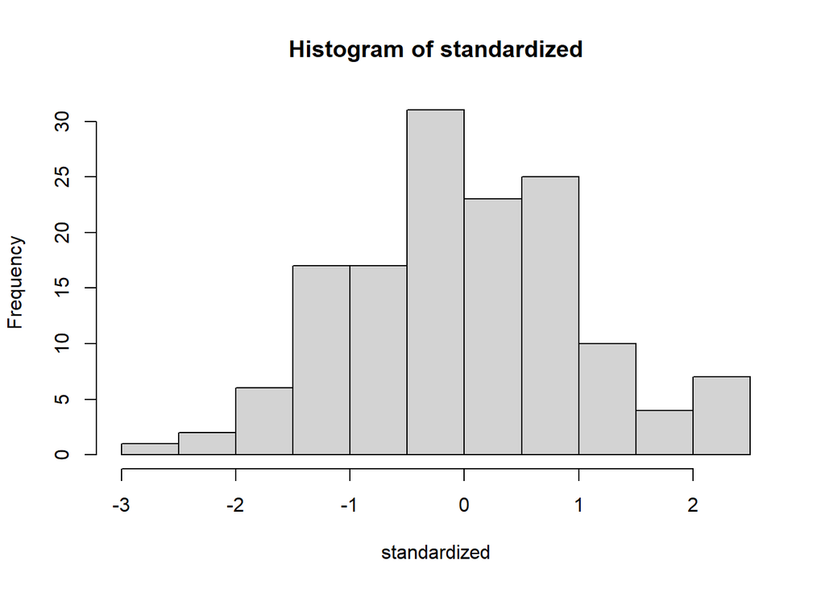

```r
hist(standardized) # close to normal
```

Linearity assumption

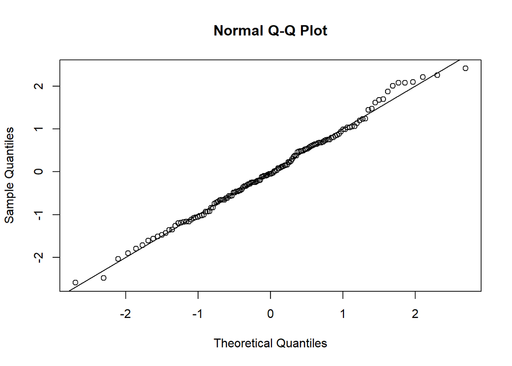

```r
qqnorm(standardized)
abline(0,1) #close to linear
```

Homoscedasticty assumption (homogeneity of variance)

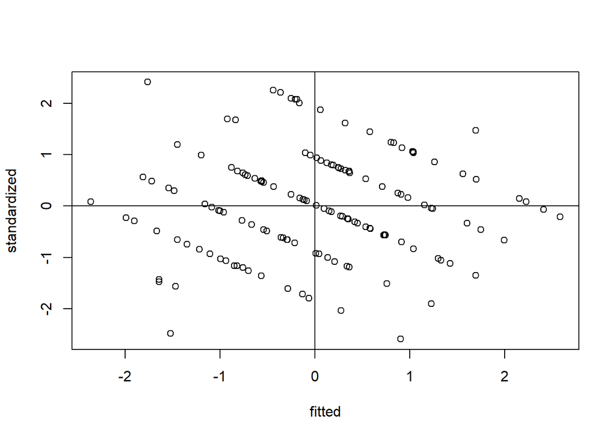

```r
plot(fitted, standardized)
abline(0,0)
abline(v=0)
```

Multicollinearity assumption

```r
vif(model.comp1)
```

```
##             age             sex      STAI_trait        pain_cat     mindfulness
##        1.591115        1.192992        2.196188        1.882257        1.476234
## cortisol_saliva
##        1.747773
```

## Model comparison

Create the simple model and get the results of the model that needs to be reported based on the What to report section.

```r
library(sjPlot)
library(sjmisc)
library(sjlabelled)
require(kableExtra)
library(broom)
model1 <- lm(pain ~
               sex +
               age, data = noout)
summary(model1)
```

```
##
## Call:
## lm(formula = pain ~ sex + age, data = noout)
##
## Residuals:
##     Min      1Q  Median      3Q     Max
## -3.6948 -0.8913  0.0599  0.9122  3.3052
##
## Coefficients:
##             Estimate Std. Error t value Pr(>|t|)
## (Intercept)  8.29154    0.94502   8.774 5.33e-15 ***
## sexmale     -0.01571    0.22471  -0.070 0.944372
## age         -0.08174    0.02315  -3.531 0.000562 ***
## ---
## Signif. codes:  0 '***' 0.001 '**' 0.01 '*' 0.05 '.' 0.1 ' ' 1
##
## Residual standard error: 1.34 on 140 degrees of freedom
## Multiple R-squared:  0.08217,    Adjusted R-squared:  0.06906
## F-statistic: 6.267 on 2 and 140 DF,  p-value: 0.002473
```

```r
glance(model1)
```

```
## # A tibble: 1 x 12
##   r.squared adj.r.squared sigma statistic p.value    df logLik   AIC   BIC
##       <dbl>         <dbl> <dbl>     <dbl>   <dbl> <dbl>  <dbl> <dbl> <dbl>
## 1    0.0822        0.0691  1.34      6.27 0.00247     2  -243.  494.  506.
## # ... with 3 more variables: deviance <dbl>, df.residual <int>, nobs <int>
```

```r
tab_model(model1, show.std = T, show.df = T, show.aic = T, show.stat = T)
```

|  | pain |  |  |  |  |  |  |
| --- | --- | --- | --- | --- | --- | --- | --- |
| Predictors | Estimates | std. Beta | CI | standardized CI | Statistic | p | df |
| (Intercept) | 8.29 | 0.01 | 6.42 – 10.16 | -0.22 – 0.23 | 8.77 | **<0.001** | 140.00 |
| sex [male] | -0.02 | -0.01 | -0.46 – 0.43 | -0.33 – 0.31 | -0.07 | 0.944 | 140.00 |
| age | -0.08 | -0.29 | -0.13 – -0.04 | -0.45 – -0.13 | -3.53 | **0.001** | 140.00 |
| Observations | 143 |  |  |  |  |  |  |
| R<sup>2</sup> / R<sup>2</sup> adjusted | 0.082 / 0.069 |  |  |  |  |  |  |
| AIC | 494.487 |  |  |  |  |  |  |

Create the more complex model based on the results of the model diagnostics. Also, get the results that needs to be reported based on the What to report section.

```r
model2 <- lm(pain ~
                   age +
                   sex +
                   STAI_trait +
                   pain_cat +
                   mindfulness +
                   cortisol_saliva, data = noout)

summary(model2)
```

```
##
## Call:
## lm(formula = pain ~ age + sex + STAI_trait + pain_cat + mindfulness +
##     cortisol_saliva, data = noout)
##
## Residuals:
##      Min       1Q   Median       3Q      Max
## -2.75697 -0.71344 -0.05378  0.71404  2.56441
##
## Coefficients:
##                  Estimate Std. Error t value Pr(>|t|)
## (Intercept)      0.714473   1.669977   0.428  0.66945
## age             -0.027376   0.024046  -1.138  0.25692
## sexmale          0.358725   0.202087   1.775  0.07812 .
## STAI_trait      -0.001621   0.027633  -0.059  0.95331
## pain_cat         0.088986   0.029831   2.983  0.00338 **
## mindfulness     -0.087928   0.122844  -0.716  0.47536
## cortisol_saliva  0.577664   0.121893   4.739 5.34e-06 ***
## ---
## Signif. codes:  0 '***' 0.001 '**' 0.01 '*' 0.05 '.' 0.1 ' ' 1
##
## Residual standard error: 1.105 on 136 degrees of freedom
## Multiple R-squared:  0.3938, Adjusted R-squared:  0.367
## F-statistic: 14.72 on 6 and 136 DF,  p-value: 6.49e-13
```

```r
tab_model(model2, show.std = T, show.df = T, show.stat = T)
```

|  | pain |  |  |  |  |  |  |
| --- | --- | --- | --- | --- | --- | --- | --- |
| Predictors | Estimates | std. Beta | CI | standardized CI | Statistic | p | df |
| (Intercept) | 0.71 | -0.12 | -2.59 – 4.02 | -0.31 – 0.07 | 0.43 | 0.669 | 136.00 |
| age | -0.03 | -0.10 | -0.07 – 0.02 | -0.26 – 0.07 | -1.14 | 0.257 | 136.00 |
| sex [male] | 0.36 | 0.26 | -0.04 – 0.76 | -0.03 – 0.55 | 1.78 | 0.078 | 136.00 |
| STAI_trait | -0.00 | -0.01 | -0.06 – 0.05 | -0.20 – 0.19 | -0.06 | 0.953 | 136.00 |
| pain_cat | 0.09 | 0.27 | 0.03 – 0.15 | 0.09 – 0.45 | 2.98 | **0.003** | 136.00 |
| mindfulness | -0.09 | -0.06 | -0.33 – 0.16 | -0.22 – 0.10 | -0.72 | 0.475 | 136.00 |
| cortisol_saliva | 0.58 | 0.42 | 0.34 – 0.82 | 0.24 – 0.59 | 4.74 | **<0.001** | 136.00 |
| Observations | 143 |  |  |  |  |  |  |
| R<sup>2</sup> / R<sup>2</sup> adjusted | 0.394 / 0.367 |  |  |  |  |  |  |

Compare the two models.

```r
anova(model1, model2)
```

```
## Analysis of Variance Table
##
## Model 1: pain ~ sex + age
## Model 2: pain ~ age + sex + STAI_trait + pain_cat + mindfulness + cortisol_saliva
##   Res.Df    RSS Df Sum of Sq      F   Pr(>F)
## 1    140 251.38
## 2    136 166.04  4    85.341 17.475 1.36e-11 ***
## ---
## Signif. codes:  0 '***' 0.001 '**' 0.01 '*' 0.05 '.' 0.1 ' ' 1
```

```r
tab_model(model1, model2, show.std = T, show.df = T, col.order = c("est", "std.est", "ci", "p"))
```

|  | pain |  |  |  | pain |  |  |  |
| --- | --- | --- | --- | --- | --- | --- | --- | --- |
| Predictors | Estimates | std. Beta | CI | p | Estimates | std. Beta | CI | p |
| (Intercept) | 8.29 | 0.01 | 6.42 – 10.16 | **<0.001** | 0.71 | -0.12 | -2.59 – 4.02 | 0.669 |
| sex [male] | -0.02 | -0.01 | -0.46 – 0.43 | 0.944 | 0.36 | 0.26 | -0.04 – 0.76 | 0.078 |
| age | -0.08 | -0.29 | -0.13 – -0.04 | **0.001** | -0.03 | -0.10 | -0.07 – 0.02 | 0.257 |
| STAI_trait |  |  |  |  | -0.00 | -0.01 | -0.06 – 0.05 | 0.953 |
| pain_cat |  |  |  |  | 0.09 | 0.27 | 0.03 – 0.15 | **0.003** |
| mindfulness |  |  |  |  | -0.09 | -0.06 | -0.33 – 0.16 | 0.475 |
| cortisol_saliva |  |  |  |  | 0.58 | 0.42 | 0.34 – 0.82 | **<0.001** |
| Observations | 143 |  |  |  | 143 |  |  |  |
| R<sup>2</sup> / R<sup>2</sup> adjusted | 0.082 / 0.069 |  |  |  | 0.394 / 0.367 |  |  |  |

```r
glance(model1) %>%
  dplyr::select(adj.r.squared, sigma, AIC, BIC, p.value)
```

```
## # A tibble: 1 x 5
##   adj.r.squared sigma   AIC   BIC p.value
##           <dbl> <dbl> <dbl> <dbl>   <dbl>
## 1        0.0691  1.34  494.  506. 0.00247
```

```r
glance(model2) %>%
  dplyr::select(adj.r.squared, sigma, AIC, BIC, p.value)
```

```
## # A tibble: 1 x 5
##   adj.r.squared sigma   AIC   BIC  p.value
##           <dbl> <dbl> <dbl> <dbl>    <dbl>
## 1         0.367  1.10  443.  467. 6.49e-13
```